# Manistee River Loop

June 1, 2019

# 1 Introduction

Aside from data science and medical informatics, one of my top interests is the outdoors - hiking, fishing, backpacking, and canoeing are just some of the ways I like to spend my free time. Since a lot of my professional portfolio is under NDA, I thought I would demonstrate some same skills I’ve to used, say, [build analytics to predict acute decompensation in general ward and COVID-19 patients](https://doi.org/10.2196/25066). While some of my other sample projects cover the use of Python (and associated libraries like keras/TensorFlow, pandas, etc) in more traditional medical informatics contexts, in this document I’d like to demonstrate my use of R in a lighter application.

# 2 Library imports

```r
library('plotKML') # read GPX files
library('geosphere') # distance calculations on sphere
library('zoo')
library('ggmap') # make plots on maps
library('knitr') # Rmd formatting
library('kableExtra') # Rmd table formatting
```

# 3 Data I/O

The [AllTrails](https://www.alltrails.com/) application used to trace our journey provides the user with raw GPX files to download. [GPS Exchange (GPS)](https://docs.fileformat.com/gis/gpx/) files are based on XML, meaning that they use tags to denote different data structures within the file. The core elements include:

- **Tracks:** an ordered list of points describing a path taken using GPS. These are the main subjects of our analysis.
- **Routes:** an ordered list of pre-defined points that describe the route taken. For the purposes of this document, routes are not used.
- **Waypoints:** these are user-defined points usually associated with metadata such as a comment or link to an image. They are not typically ordered.

In the case of our GPX files, track elements contain latitude, longitude, elevation, and timestamp information, while the waypoints contain latitude, longitude, and a short comment.

## 3.1 Extracting tracks

The `readGPX()` function is part of the `plotKML` library, and parses this the GPX files into an R structure of nested lists. The relevant tracks are then selected and transformed into dataframes, and our multi-day itinerary is concatenated into one dataset.

```r
# Read GPX Files
data.1 <- readGPX('./data/2019-06-01.gpx')
data.2 <- readGPX('./data/2019-06-02.gpx')

# Extract tracks; gather into one dataframe
data.1$tracks <- data.frame(data.1$tracks[[1]][2])
data.2$tracks <- data.frame(data.2$tracks)
colnames(data.1$tracks) <- colnames(data.2$tracks)

data <- rbind(data.1$tracks, data.2$tracks)

# Print first few rows for display
kable(head(data)) %>%
  kable_styling(bootstrap_options = 'striped')
```

| lon | lat | ele | time |
| --- | --- | --- | --- |
| -85.86162 | 44.28380 | 211.0 | 2019-06-01T10:59:35Z |
| -85.86163 | 44.28382 | 211.0 | 2019-06-01T10:59:44Z |
| -85.86167 | 44.28383 | 211.01 | 2019-06-01T10:59:47Z |
| -85.86172 | 44.28383 | 211.21 | 2019-06-01T10:59:50Z |
| -85.86176 | 44.28383 | 211.36 | 2019-06-01T10:59:52Z |
| -85.86179 | 44.28386 | 211.69 | 2019-06-01T10:59:55Z |

## 3.2 Extracting waypoints

Next, waypoints are extracted in a similar fashion:

```r
# Gather waypoints
waypoints <- rbind(data.1$waypoints, data.2$waypoints)

# Print first few waypoints for display
kable(head(waypoints)) %>%
  kable_styling(bootstrap_options = 'striped')
```

| lon | lat | name | desc |
| --- | --- | --- | --- |
| -85.87232 | 44.29162 | Campsite |  |
| -85.87291 | 44.29159 | Unmarked trail fork |  |
| -85.87522 | 44.29333 | NCT Juncture |  |
| -85.87479 | 44.29406 | Ridgetop, small campsite |  |
| -85.87459 | 44.29872 | campsite |  |
| -85.87053 | 44.30369 | red hill lookout junction |  |

```r
# Calculate distances
data$distances <- distGeo(data[,c('lon', 'lat')])
data$distances[length(data$distances)] <- 0

# Convert from meters to miles
data$cum.distance <- cumsum(data$distances)/1609.344
total.distance <- sum(data$distances[-length(data$distances)])/1609.344

# Calculate elevation
data$ele <- as.numeric(data$ele)
data$ele.med <- rollmedian(data$ele, 51, na.pad=TRUE)
```

```r
# Calculate bounds of map
bounds <- data.frame(matrix(0, 2, 2), row.names=c('x','y'))
colnames(bounds) = c('min', 'max')
bounds['x', 'min'] <- min(data$lon)
bounds['x', 'max'] <- max(data$lon)
bounds['y', 'min'] <- min(data$lat)
bounds['y', 'max'] <- max(data$lat)

# Map lookup
map <- get_map(location=c(
    left=min(data$lon) - 0.1*diff(range(data$lon)),
    right=max(data$lon) + 0.2*diff(range(data$lon)),
    top=max(data$lat) + 0.2*diff(range(data$lat)),
    bottom=min(data$lat)) - 0.1*diff(range(data$lat)),
  maptype='terrain')
```

```r
# Display table with descriptive statistics
tbl <- data.frame(
  total.distance=sprintf('%0.2f miles', total.distance),
  max.elevation=sprintf('%0.2f feet', max(data$ele.med, na.rm=T)),
  min.elevation=sprintf('%0.2f feet', min(data$ele.med, na.rm=T)),
  total.uphill=sprintf('%0.2f feet', sum(diff(data$ele.med, na.rm=T)[diff(data$ele.med, na.rm=T) > 0], na.rm=T)),
  total.downhill=sprintf('%0.2f feet', -sum(diff(data$ele.med, na.rm=T)[diff(data$ele.med, na.rm=T) < 0], na.rm=T))
)

colnames(tbl) <- c('Total Distance', 'Max. Elevation', 'Min. Elevation', 'Total Uphill Distance', 'Total Downhill Distance')

kable(tbl) %>%
  kable_styling(bootstrap_options = 'striped')
```

| Total Distance | Max. Elevation | Min. Elevation | Total Uphill Distance | Total Downhill Distance |
| --- | --- | --- | --- | --- |
| 20.26 miles | 342.00 feet | 210.00 feet | 532.97 feet | 535.97 feet |

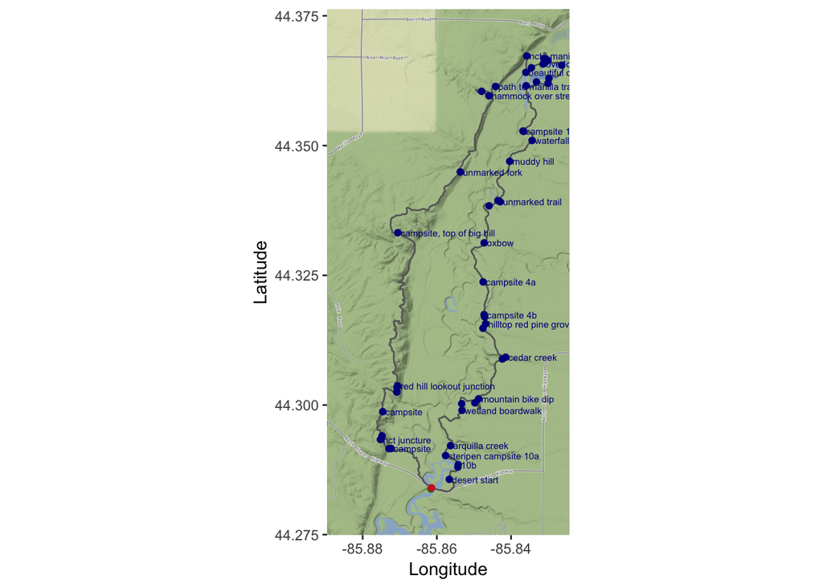

```r
# Plot map of route
ggmap(map) +
  geom_path(data=data, aes(x=lon, y=lat), color='gray40') +
  geom_point(data=waypoints, aes(x=lon, y=lat), color='blue4') +
  geom_text(data=waypoints, size=2, nudge_x=0.015*diff(range(data$lon)), color='blue4', check_overlap=T, #fontface='bold',
            aes(x=lon, y=lat, label=tolower(name), hjust='left')) +
  geom_point(data=data[1,], color='green4', aes(x=lon, y=lat)) +
  geom_point(data=data[nrow(data),], color='firebrick3', aes(x=lon, y=lat)) +
  xlab('Longitude') + ylab('Latitude')
```

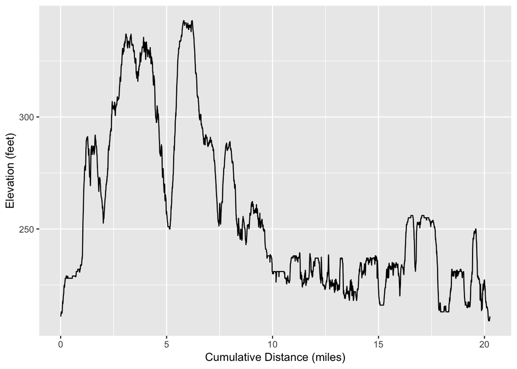

```r
ggplot(data=data, aes(x=cum.distance, y=ele)) +
  geom_line() +
  xlab('Cumulative Distance (miles)') + ylab('Elevation (feet)')
```